# Imputation for Time Series

Time Series

Imputation using Kalman Smoothing for Time Series Data

Yeongeun Jeon , Jung In Seo  
10-13-2020

- Data 출처 : [Data Mining for Business Analytics](https://www.dataminingbook.com/book/r-edition)에서 사용한 미국 철도 회사 “Amtrak”에서 수집한 1991년 1월~2004년 3월까지 매달 환승 고객 수

# **Structural Time Series Model**

$$\begin{aligned}
Y_{t}&=Z^{T}_{t}\alpha_{t}+\epsilon_{t},~~~~~~~\epsilon_{t}\sim N_{m}(0,H_{t}), \\
\alpha_{t+1}&=T_{t}\alpha_{t}+R_{t}\eta_{t},~~~\eta_{t}\sim N_{q}(0,Q_{t}),\\
\alpha_{1} &\sim N_{p} (\mu_{1}, P_{1})
\end{aligned}$$

- 첫번째는 관측방정식, 두번째는 상태방정식이다.
  - $Y_{t}$ : 시점 $t$에서 관측값
  - $\alpha_{t}$ : 시점 $t$에서 관측할 수 없는 상태 (시계열에서 추세, 계절성 등이 상태가 될 수 있음)
    - 직접 관찰할 수 없지만 시간이 지남에 따라 어떻게 변화하는지 알고 있다고 가정하는 것이 합리적
    - 시간이 지남에 따라 어떻게 변화하는지 정의
  - $Z_{t}$, $T_{t}$, $R_{t}$ : 0과 1을 포함하여 알고 있는 값과 미지의 모수를 포함하는 행렬
    - $Z_{t}$ : $p\times m$ 결과 행렬 (Output Matirx)
    - $T_{t}$ : $p\times p$ 전이 행렬 (Transition Matrix)
    - $R_{t}$ : $p\times q$ 제어 행렬 (Control Matrix)
  - $\epsilon_{t}$, $\eta_{t}$ : 오차로써, 연속적으로 상관관계가 없으며 또한 모든 기간 동안 서로 상관관계가 없는 것으로 가정한다.
    - $\epsilon_{t}$ : $m\times m$ 분산공분산행렬(Variance-covariance Matrix) $H_{t}$을 가진 $m\times 1$ 벡터
    - $\eta_{t}$ : $q\times q$ 상태확산행렬(State Diffusion Matrix) $Q_{t}$을 가진 $q \times 1$ 벡터 ($q\le d$)
- 상태 $\alpha_{t}$를 추정하는 방법은 두 가지가 있다.
  - Kalman Filtering
    - 관측값을 예측할 때 사용
  - Kalman Smoothing
    - `결측값`이 있을 때 유용

# **Kalman Smoothing**

- 특정 기간 또는 모든 시간동안 주어진 시계열 데이터 $y_{1}, \ldots, y_{T}$가 주어졌을 때, 상태 $\alpha_{t}(t<T)$를 추정하는 방법
- $\hat{\alpha}_{t} = E(\alpha_{t}|y_{1},\ldots, y_{T})$
  - $\alpha_{t}|y_{1},\ldots, y_{T}$의 사후 분포를 이용하여 계산
    - 정확한 계산식은 [Dynamic Linear Models with R (p.62)](https://link.springer.com/book/10.1007/b135794) 또는 [Time Series Analysis by State Space Methods (p.96~97)](https://oxford.universitypressscholarship.com/view/10.1093/acprof:oso/9780199641178.001.0001/acprof-9780199641178) 참고
- 과거, 현재 그리고 미래 데이터를 이용하기 때문에, Kalman Filtering보다 정확

# **imputeTS Package**

- [`imputeTS` Package](https://cran.r-project.org/web/packages/imputeTS/vignettes/imputeTS-Time-Series-Missing-Value-Imputation-in-R.pdf)은 단변량 시계열 데이터 (Univariate time series)에 결측값을 Imputation하기 위해 개발된 패키지이다.
- [`na_kalmna()`](https://github.com/SteffenMoritz/imputeTS/blob/master/R/na_kalman.R)함수로 Kalman Smoothing 방법을 이용한 Imputation을 할 수 있다.
- 자세한 옵션은 [여기](https://www.rdocumentation.org/packages/imputeTS/versions/3.2/topics/na_kalman)를 참고한다.

```
na_kalman(x, model = "StructTS", smooth = TRUE, ...)
```

- x : 결측값이 있는 시계열 데이터 또는 수치형 벡터
- model : Kalman Smoothing이 수행되는 상태 공간 모형(State Space Model)
  - `auto.arima` : auto.arima에 의해 적합된 ARIMA 모형
    - ARIMA 모형은 Structural Time Series Model으로 표현 가능
  - `StructTS` : 최대 우도(Maximum Likelihood)에 의해 적합된 structural 모형
- smooth : `TRUE`이면, Kalman Smoothing, `FALSE`이면 Kalmna Run(Kalman Filtering)

## **Process**

> `na_kalmna()`의 Imputation 과정은 다음과 같다.
1. 주어진 시계열 데이터의 `NA`의 위치를 파악한다.
2. 시계열 데이터를 model에 명시한 함수를 이용하여 적합한다.
3. 적합된 모형을 이용하여 Kalman Smoothing/Run 방법으로 상태 $\hat{\alpha}_{t}$를 추정한다.
4. `NA` 를 추정된 $\hat{y}_{t}=Z^{T}_{t}\hat{\alpha}_{t}$로 대체한다.

## **StructTS**

- `stats` Package에 있는 함수로, 주어진 시계열 데이터를 structural 모형에 적합한다.
  - 최대 우도를 이용해 structural 모형의 모수(상태와 관측값의 분산)를 찾는다.
- 자세한 옵션은 [여기](https://www.rdocumentation.org/packages/stats/versions/3.6.2/topics/StructTS), 함수 내부는 [여기](https://github.com/SurajGupta/r-source/blob/master/src/library/stats/R/StructTS.R)를 참조한다.

```
StructTS(x, type = c("level", "trend", "BSM"), ...)
```

- x : 단변량 시계열 데이터
- type : 생략할 경우, x의 frequency가 1보가 크면, “BSM”, 아니면 Local Linear Trend Model
  - level : Local Level Model
    - $Z^{T}_{t} = 1$, $T_{t} = 1$, $\alpha_{t}=\mu_{t}$, $R_{t} = 1$, $\eta_{t} = \xi_{t}$일 때, 모형식은 다음과 같다.

$$\begin{aligned}
Y_{t} &= \mu_{t} + \epsilon_{t},~~~~\epsilon_{t}\sim N(0, \sigma^2_{\epsilon})\\
\mu_{t+1} &= \mu_{t} + \xi_{t}, ~~~\xi_{t}\sim N(0,\sigma^2_{\xi }),
\end{aligned}$$

- - trend : Local Linear Trend Model
    - $Z^{T}_{t} = (1, 0)$, $T_{t} = \left[\begin{matrix} 1 & 1\\ 0 & 1 \end{matrix}\right]$, $\alpha_{t}=(\mu_{t}, \delta_{t})^{T}$, $R_t=\left[\begin{matrix} 1 & 0 \\ 0 & 1 \end{matrix}\right]$, $\eta_{t}=(\xi_{t},\zeta_{t})^{T}$일 때, 모형식은 다음과 같다.

$$\begin{aligned}
Y_{t} &= \mu_{t} + \epsilon_{t},~~~~~~~~~~\epsilon_{t}\sim N(0, \sigma^2_{\epsilon})\\
\mu_{t+1} &= \mu_{t} + \delta_{t} + \xi_{t}, ~~~\xi_{t}\sim N(0,\sigma^2_{\xi }),\\
\delta_{t+1} &= \delta_{t} + \zeta_{t}, ~~~~~~~~~~~~\zeta_{t}\sim N(0,\sigma^2_{\zeta}),
\end{aligned}$$

- - BSM : Basic Structural Model로써, Local Linear Trend + Seasonal Component
    - $Z^{T}_{t} = (1,0,1,\ldots, 0)$, $T_{t} = \left[\begin{smallmatrix} 1 & 1 & \\ 0 & 1 & \\ & & -1 & - 1 & \cdots & -1 & -1 \\ & & 1 & 0 & \cdots &0& 0\\ & & 0 & 1 & \cdots & 0 &0 \\ & & \vdots &\vdots &\vdots &\vdots &\vdots &\\ & & 0 & 0 & \cdots & 1 & 0 \end{smallmatrix}\right]$, $\alpha_{t} = (\mu_{t}, \delta_{t}, \tau_{t}, \ldots, \tau_{t-S+2})^{T}$, $R_{t}=\left[\begin{smallmatrix}1 & 0 \\ 0 & 1 \\ & & 1 \\ & & 0 \\ & & \vdots \\ & & 0 \\ \end{smallmatrix}\right]$, $\eta_{t}=(\xi_{t}, \zeta_{t},\omega_{t})^{T}$일 때, 모형식은 다음과 같다.

$$\begin{aligned}
Y_{t} &= \mu_{t} + \tau_{t} + \epsilon_{t},~~~~\epsilon_{t}\sim N(0, \sigma^2_{\epsilon})\\
\mu_{t+1} &= \mu_{t} + \delta_{t} + \xi_{t}, ~~~~~~~~~\xi_{t}\sim N(0,\sigma^2_{\xi }),\\
\delta_{t+1} &= \delta_{t} + \zeta_{t}, ~~~~~~~~~~~~~~~~~~~~~\zeta_{t}\sim N(0,\sigma^2_{\zeta})\\
\tau_{t+1}&=-\sum_{s=1}^{S-1} \tau_{t+1-s} + \omega_{t}, ~~~~~~~~~~\omega_{t}\sim N(0,\sigma^2_{\omega })
\end{aligned}$$

# **Application**

## **Data 불러오기**

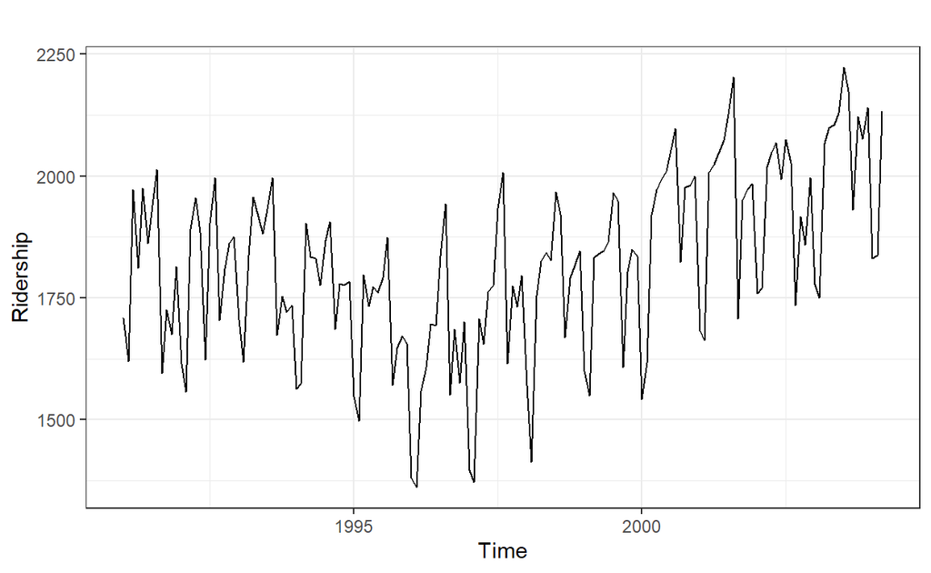

```
pacman::p_load("dplyr", "xts", "ggplot2", "imputeTS")

# In Mac
# guess_encoding("Amtrak.csv")
# Amtrak.data <- read.csv("Amtrak.csv", fileEncoding="EUC-KR")

Amtrak.data  <- read.csv("C:/Users/User/Desktop/Amtrak.csv")
ridership.ts <- ts(Amtrak.data$Ridership, start=c(1991,1), end=c(2004,3), freq=12)
autoplot(ridership.ts) +
  labs(y="Ridership") +
  theme_bw()
```

## **결측값 생성**

```
# NA 생성성
set.seed(100)
loc <- sample(1:length(ridership.ts), 5)    # Randomly Location

ridership.ts.NA <- ridership.ts
ridership.ts.NA[loc] <- NA

# NA 갯수와 위치
xts(ridership.ts.NA, order = as.Date(ridership.ts.NA))
```

```
               [,1]
1991-01-01 1708.917
1991-02-01 1620.586
1991-03-01 1972.715
1991-04-01       NA
1991-05-01 1974.964
1991-06-01 1862.356
1991-07-01 1939.860
1991-08-01 2013.264
1991-09-01 1595.657
1991-10-01 1724.924
1991-11-01 1675.667
1991-12-01 1813.863
1992-01-01 1614.827
1992-02-01 1557.088
1992-03-01 1891.223
1992-04-01 1955.981
1992-05-01 1884.714
1992-06-01 1623.042
1992-07-01 1903.309
1992-08-01 1996.712
1992-09-01 1703.897
1992-10-01 1810.000
1992-11-01 1861.601
1992-12-01 1875.122
1993-01-01 1705.259
1993-02-01 1618.535
1993-03-01 1836.709
1993-04-01 1957.043
1993-05-01 1917.185
1993-06-01 1882.398
1993-07-01 1933.009
1993-08-01 1996.167
1993-09-01 1672.841
1993-10-01 1752.827
1993-11-01 1720.377
1993-12-01 1734.292
1994-01-01 1563.365
1994-02-01 1573.959
1994-03-01 1902.639
```

[output cut: 105 more lines]

```
2003-01-01 1778.033
2003-02-01 1749.489
2003-03-01 2066.466
2003-04-01 2098.899
2003-05-01 2104.911
2003-06-01 2129.671
2003-07-01       NA
2003-08-01 2174.360
2003-09-01 1931.406
2003-10-01 2121.470
2003-11-01 2076.054
2003-12-01 2140.677
2004-01-01 1831.508
2004-02-01 1838.006
2004-03-01 2132.446
```

```
as.Date(ridership.ts.NA)
```

```
  [1] "1991-01-01" "1991-02-01" "1991-03-01" "1991-04-01" "1991-05-01"
  [6] "1991-06-01" "1991-07-01" "1991-08-01" "1991-09-01" "1991-10-01"
 [11] "1991-11-01" "1991-12-01" "1992-01-01" "1992-02-01" "1992-03-01"
 [16] "1992-04-01" "1992-05-01" "1992-06-01" "1992-07-01" "1992-08-01"
 [21] "1992-09-01" "1992-10-01" "1992-11-01" "1992-12-01" "1993-01-01"
 [26] "1993-02-01" "1993-03-01" "1993-04-01" "1993-05-01" "1993-06-01"
 [31] "1993-07-01" "1993-08-01" "1993-09-01" "1993-10-01" "1993-11-01"
 [36] "1993-12-01" "1994-01-01" "1994-02-01" "1994-03-01" "1994-04-01"
 [41] "1994-05-01" "1994-06-01" "1994-07-01" "1994-08-01" "1994-09-01"
 [46] "1994-10-01" "1994-11-01" "1994-12-01" "1995-01-01" "1995-02-01"
 [51] "1995-03-01" "1995-04-01" "1995-05-01" "1995-06-01" "1995-07-01"
 [56] "1995-08-01" "1995-09-01" "1995-10-01" "1995-11-01" "1995-12-01"
 [61] "1996-01-01" "1996-02-01" "1996-03-01" "1996-04-01" "1996-05-01"
 [66] "1996-06-01" "1996-07-01" "1996-08-01" "1996-09-01" "1996-10-01"
 [71] "1996-11-01" "1996-12-01" "1997-01-01" "1997-02-01" "1997-03-01"
```

[output cut: 17 more lines]

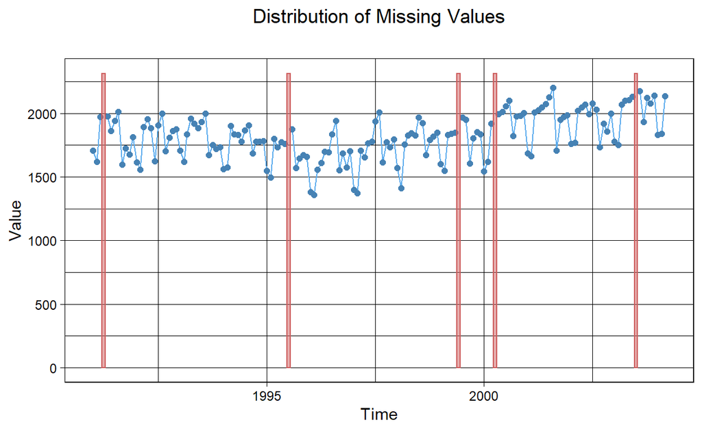

```
ggplot_na_distribution(as.numeric(ridership.ts.NA),
                       x_axis_labels = as.Date(ridership.ts.NA), subtitle = "") +
  ggplot2::theme(plot.title = ggplot2::element_text(hjust = 0.5))
```

```
# ggplot_na_distribution(as.numeric(ridership.ts),
#                        x_axis_labels = as.Date(Amtrak.data$Month, format = "%m/%d/%Y"))
```

## **Imputation**

```
# 1. Using Basic Structural Model (Local Linear Trend + Seasonal) Due to frequency of ridership.ts.NA
Kalman.Imp <- na_kalman(ridership.ts.NA)

# Imputation 확인Kalman.Imp[loc]
```

```
[1] 1849.782 1945.737 2221.376 1930.777 1817.434
```

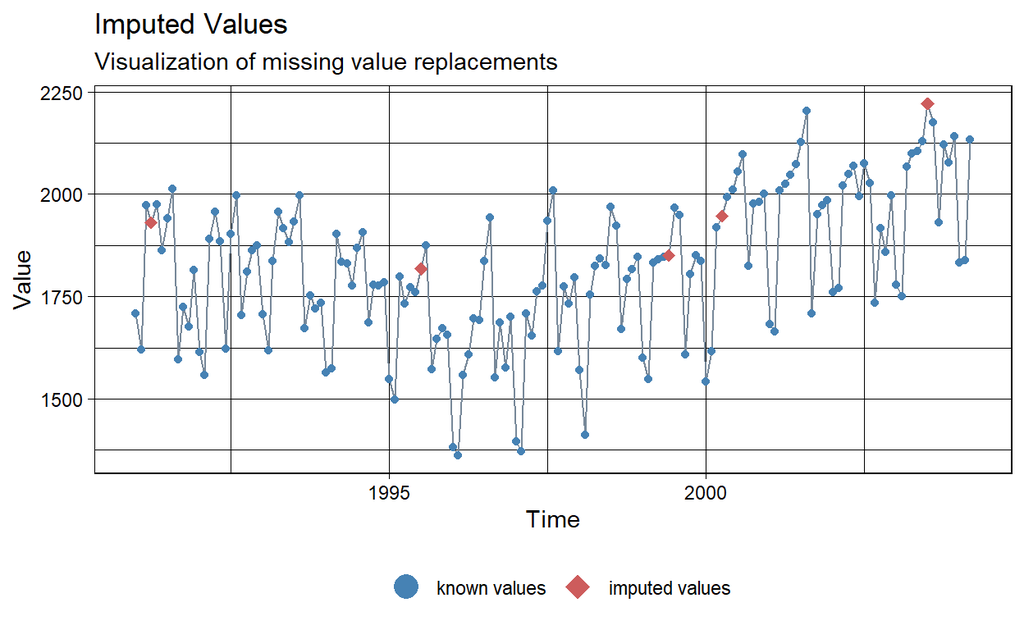

```
ggplot_na_imputations(ridership.ts.NA, Kalman.Imp, x_axis_labels = as.Date(ridership.ts.NA))
```

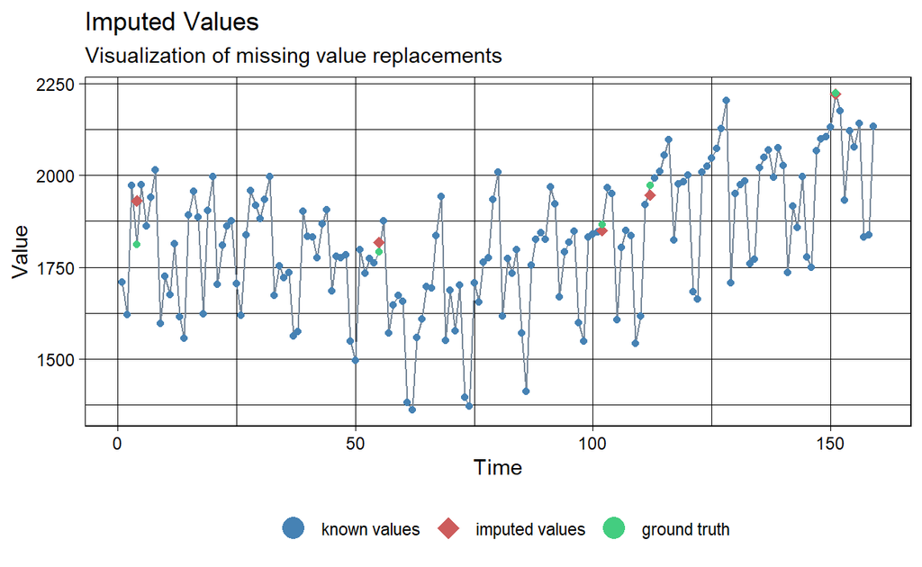

```
# 실제값과 비교비교
ggplot_na_imputations(ridership.ts.NA, Kalman.Imp, ridership.ts)
```

```
# 2. Using Local Linear Trend
Kalman.Imp <- na_kalman(ridership.ts.NA, type="trend")

# Imputation 확인Kalman.Imp[loc]
```

```
[1] 1810.990 1874.212 2021.916 1768.566 1692.744
```

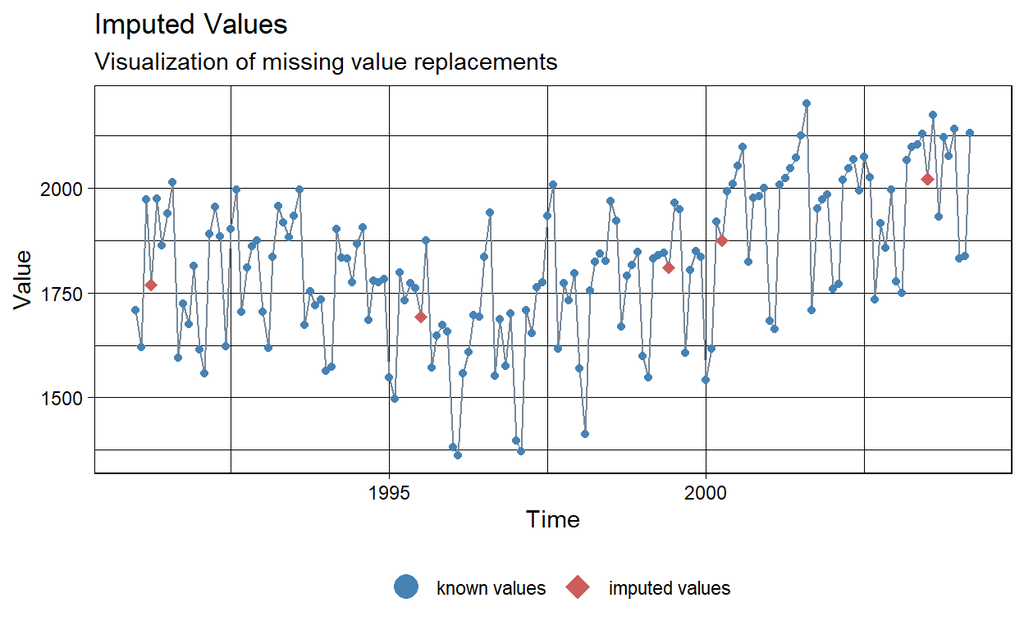

```
ggplot_na_imputations(ridership.ts.NA, Kalman.Imp, x_axis_labels = as.Date(ridership.ts.NA))
```

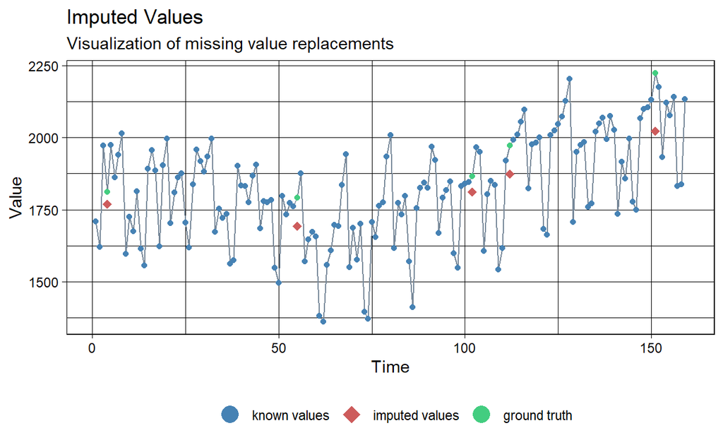

```
# 실제값과 비교비교
ggplot_na_imputations(ridership.ts.NA, Kalman.Imp, ridership.ts)
```

```
# 3. Auto.arima
Kalman.Imp.arima <- na_kalman(ridership.ts.NA, model = "auto.arima")

# Imputation 확인Kalman.Imp.arima[loc]
```

```
[1] 1848.001 1952.100 2190.084 1990.073 1855.564
```

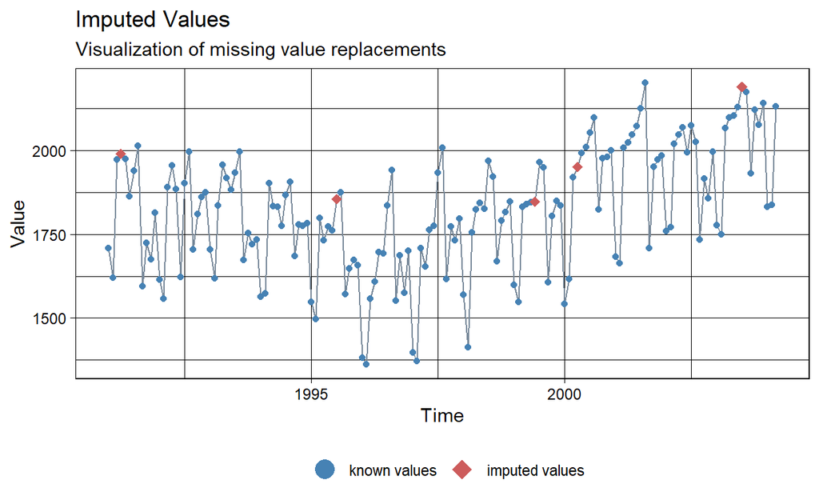

```
ggplot_na_imputations(ridership.ts.NA, Kalman.Imp.arima, x_axis_labels = as.Date(ridership.ts.NA))
```

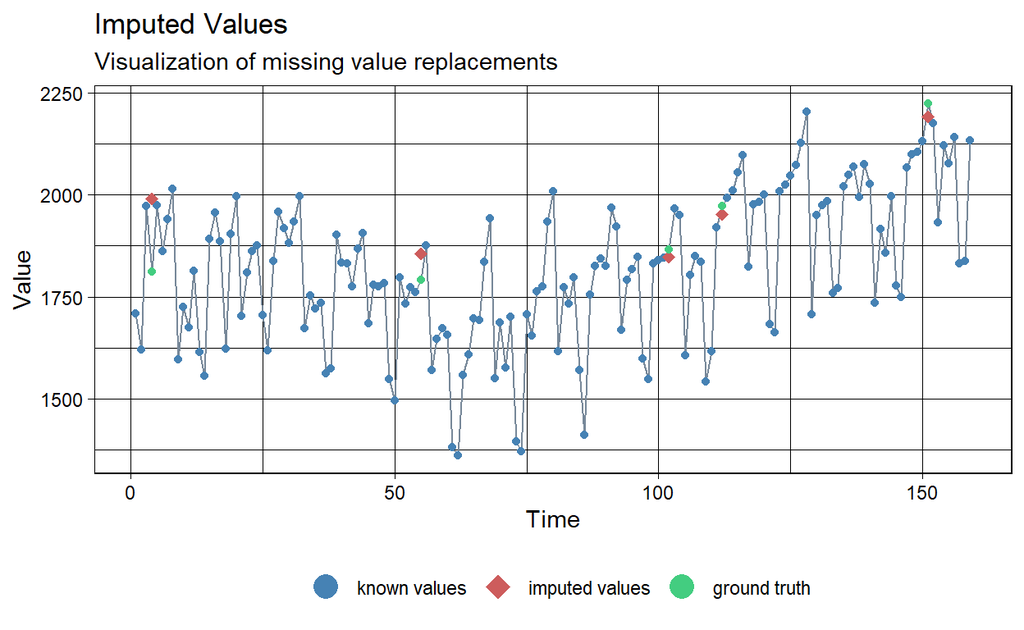

```
# 실제값과 비교비교
ggplot_na_imputations(ridership.ts.NA, Kalman.Imp.arima, ridership.ts)
```